# Multiple Linear Regression

Monika Peteva Petkova

mpetevap@uni-sofia.bg, monikapetevapetkova@gmail.com

2021

# Multiple Linear Regression

Here we assume that $\mathbb{D}Y < \infty$ and $\mathbb{D}X^{(j)} < \infty$, $j = 1, 2, ..., r$.

Regression analysis study the form of the relationship between numerical random variables $X^{(1)}, X^{(2)}, ..., X^{(r)}$ and $Y$. More precisely its aim is by knowing $X^{(1)}, X^{(2)}, ..., X^{(r)}$ and the regression model to predict $Y$.

For example, the price $Y$ of a new home depends on many factors: $X^{(1)}$ - the number of bedrooms, $X^{(2)}$ - the number of bathrooms, $X^{(3)}$ - the location of the house, etc.

People develop rules of thumb to help figure out the value. These may be:

$+\$30,000$ for an extra bedroom

$+\$15,000$ for an extra bathroom

$-\$10,000$ for the busy street.

These are intuitive uses of a multiple linear regression model to explain the cost of a house based on several variables.

$X^{(1)}, X^{(2)}, ..., X^{(r)}$ are called **independent (or explanatory) variables (or predictors, or regressors) /независими променливи/**. I.e. we have multiple explanatory variables. If some of them are correlated we speak about **multicollinearity /мултиколинеарност/**. In such cases we would difficultly differentiate the clear effects of separate independent random variables. In presanse of multicollinearity the estimators considered here are again unbiased, however their standars errors will be bigger. **If there is no multicollinearity the coefficients of the models with more independent variables will be the same as the coefficients before the same variables in models with less independent variables.**

$Y$ is called **dependent (or outcome or response) variable (or regressand)** .

When there is a single dependent variable $Y$ and multiple independent variables $X^{(1)}, X^{(2)}, ..., X^{(r)}$, and **the dependence on the coefficients is linear** the analysis is called **a multiple linear regression analysis**. More precisely **the multiple linear regression model** is

$$Y = \hat{Y} + \varepsilon = \beta_0 + \beta_1 X^{(1)} + \beta_2 X^{(2)} + ... + \beta_r X^{(r)} + \varepsilon = \vec{\beta}^T\vec{X} + \varepsilon,$$
where

$$\varepsilon \in N(0, \sigma_\varepsilon^2), \quad \quad cov(X^{(j)}, \varepsilon) = 0, \,j = 1, 2, ..., r, \quad \vec{\beta} = \left(\begin{array}{c}
\beta_0\\
\beta_1\\
\beta_2\\
...\\
\beta_r
\end{array}\right), \quad \vec{X} = \left(\begin{array}{c}
1\\
X^{(1)}\\
X^{(2)}\\
...\\
X^{(r)}
\end{array}\right).$$
In practice, the above assumptions should be checked as part of the model-building process.

- **$\varepsilon$ is the random residual (error) term /случайна грешка/**

$$\varepsilon = Y - \hat{Y} = Y - \beta_0 - \beta_1 X^{(1)} - \beta_2 X^{(2)} - ... - \beta_r X^{(r)} = Y - \vec{\beta}^T\vec{X}$$

- $\beta_1$, …, $\beta_r$, are **unknown coefficients**. They will be estimated from the data by using the method of **least squares** (by minimizing the sum of square errors $\sum_{i=1}^n \varepsilon_i^2$).

**By assumption**

- $\mathbb{E}\varepsilon = 0$, and therefore,

$$\mathbb{E}Y = \beta_0 + \beta_1 \mathbb{E}X^{(1)} + \beta_2 \mathbb{E}X^{(2)} + ... + \beta_r \mathbb{E}X^{(r)},$$
$$\beta_0 = \mathbb{E}Y - \beta_1 \mathbb{E}X^{(1)} - \beta_2 \mathbb{E}X^{(2)} - ... - \beta_r \mathbb{E}X^{(r)}$$

- $cor(X^{(i)}, \varepsilon) = 0,$ $i = 1, 2, ..., r$, i.e. the independent variables $X^{(1)}, X^{(2)}, ..., X^{(r)}$ and the random error term $\varepsilon$ are uncorrelated.

Therefore, $\hat{Y}$ and $\varepsilon$ are uncorrelated and
$$\mathbb{E}(\varepsilon|X^{(1)}, X^{(2)}, ..., X^{(r)}) = \mathbb{E}\varepsilon = 0,$$
$$\mathbb{D}(\varepsilon|X^{(1)}, X^{(2)}, ..., X^{(r)}) = \mathbb{D}\varepsilon = \sigma_\varepsilon^2.$$

$\hat{Y} = \mathbb{E}(Y | X^{(1)}, X^{(2)}, ..., X^{(r)}) = \mathbb{E}(\beta_0 + \beta_1 X^{(1)} + \beta_2 X^{(2)} + ... + \beta_r X^{(r)} + \varepsilon | X^{(1)}, X^{(2)}, ..., X^{(r)})$
$$=\beta_0 + \beta_1 X^{(1)} + \beta_2 X^{(2)} + ... + \beta_r X^{(r)}$$
$$\mathbb{E}\hat{Y} = \beta_0 + \beta_1 \mathbb{E}X^{(1)} + \beta_2 \mathbb{E}X^{(2)} + ... + \beta_r \mathbb{E}X^{(r)} = \vec{\beta}^T \mathbb{E} \vec{X} = \mathbb{E}Y,$$
and the corresponding **multiple linear regression equation** (the equation of the corresponding $r+1$ dimensional hyperplane) is as follows:
$$y = \beta_0 + \beta_1 x^{(1)} + \beta_2 x^{(2)} + ... + \beta_r x^{(r)}$$

By the model assumed it is easy to see that

- $\beta_0 = \mathbb{E}(Y|X^{(1)} = 0, X^{(2)} = 0, ..., X^{(r)} = 0)$ is the **intercept** of the regression hyperplane from $Oy$ axis.
- $\beta_i = \mathbb{E}(Y|X^{(i)}+1, X^{(m)}, m \not=i) - \mathbb{E}(Y|X^{(i)}, X^{(m)}, m \not=i) = \beta_i(X^{(i)} + 1) - \beta_i X^{(i)}$ is the expected increment of the $Y$ (in its units) when $X^{(i)}$ increases with $1$ (in the units of $X^{(i)}$) and the other $X^{(m)}, m \not=i$, $m = 1, 2, ..., r$ are fixed.

When we consider the variances
$$\mathbb{D}(\hat{Y}) = \mathbb{D}(\beta_0 + \beta_1 X^{(1)} + \beta_2 X^{(2)} + ... + \beta_r X^{(r)}) = \mathbb{D}(\vec{\beta}^T{\vec{X}}) = cov(\vec{\beta}^T{\vec{X}},\vec{\beta}^T{\vec{X}}) = \vec{\beta}^T cov(\vec{X})\vec{\beta}$$
$$\mathbb{D}(Y) = \mathbb{D}(\hat{Y} + \varepsilon) = \mathbb{D}(\hat{Y}) + \mathbb{D}\varepsilon = \mathbb{D}(\beta_0 + \beta_1 X^{(1)} + \beta_2 X^{(2)} + ... + \beta_r X^{(r)}) + \mathbb{D}\varepsilon$$
$$= \mathbb{D}(\vec{\beta}^T{\vec{X}}) + \sigma_\varepsilon^2 = cov(\vec{\beta}^T{\vec{X}},\vec{\beta}^T{\vec{X}}) + \sigma_\varepsilon^2 = \vec{\beta}^T cov(\vec{X})\vec{\beta} + \sigma_\varepsilon^2$$
$$\frac{\mathbb{D}\hat{Y}}{\mathbb{D}Y} = \frac{\mathbb{D}Y - \mathbb{D}\varepsilon}{\mathbb{D}Y} = 1 - \frac{\mathbb{D}\varepsilon}{\mathbb{D}Y}$$

$$cov(Y, \hat{Y}) = cov(Y, \beta_0 + \beta_1 X^{(1)} + \beta_2 X^{(2)} + ... + \beta_r X^{(r)}) = cov(Y, \vec{\beta}^T{\vec{X}}) = \vec{\beta}^T cov(\vec{X}, Y) = cov(Y, \vec{X})\vec{\beta}$$
Moreover,

$$cov(Y, \hat{Y}) = cov(\hat{Y} + \varepsilon, \hat{Y}) = cov(\hat{Y}, \hat{Y}) + cov(\varepsilon, \hat{Y}) = cov(\hat{Y}, \hat{Y}) = \mathbb{D}\hat{Y} = \vec{\beta}^T cov(\vec{X})\vec{\beta}$$

Therefore,
$$cov(Y,\vec{X}) = \vec{\beta}^Tcov(\vec{X}), \quad cov(\vec{X}, Y) = cov(\vec{X})\vec{\beta}$$
The corresponding estimators of $\mathbb{E}Y$, $\mathbb{E}X$, $\mathbb{D}Y$, $cov(\vec{X})$, $cov(\vec{X}, Y)$ and $cor(\vec{X}, Y)$ are already known. Therefore, we can estimate the coefficients $\vec{\beta}$

$$\begin{equation}
\vec{\beta}^T = cov(Y,\vec{X})cov(\vec{X})^{-1} \iff \vec{\beta} = cov(\vec{X})^{-1}cov(\vec{X}, Y).
\label{eq:beta}
\tag{1}
\end{equation}$$

When we need to assess the quality of the model we need the following characteristic
$$cor^2(\vec{X}, Y) := \frac{cov(Y,\vec{X})cov^{-1}(\vec{X})cov(\vec{X},Y)}{\mathbb{D}Y} = \frac{cov(Y,\vec{X})\vec{\beta}}{\mathbb{D}Y} = \frac{\mathbb{D}\hat{Y}}{\mathbb{D}Y} = 1 - \frac{\mathbb{D}\varepsilon}{\mathbb{D}Y}$$
(and the corresponding estimator $R^2$) is called **coefficient of determination /коефициент на определеност/**. And, as far as
$$\mathbb{D}Y =\mathbb{D}Ycor^2(\vec{X},Y) + \mathbb{D}\varepsilon$$
$cor^2(\vec{X},Y)$ shows what part of $\mathbb{D}Y$ which is due to regression.

$1 - cor^2(\vec{X},Y)$ is called **coefficient of indetermination /коефициент на неопределеност/**. It shows part of $\mathbb{D}Y$ is due to changes of the error term, i.e. variables that are not considered in the model.

When we use these coefficients $\vec{\beta} = cov(\vec{X})^{-1}cov(\vec{X}, Y)$, the minimal value of the **Residual Standard error** (between $Y$ and $\hat{Y}$) of the model is

$$\sigma_\varepsilon = \sqrt{\mathbb{D}\varepsilon} = \sqrt{\mathbb{E}\varepsilon^2} = \sqrt{\mathbb{E}(Y - \hat{Y})^2} = \sqrt{\mathbb{E}(Y - \vec{\beta}^T\vec{X})^2} = \sqrt{\mathbb{D}Y(1-cor^2 (\vec{X},Y))}$$

The inequality
$$\mathbb{D}(Y|\vec{X} = \vec{x}) = \mathbb{D}(\vec{\beta}^T\vec{X} + \varepsilon|\vec{X} = \vec{x}) = \sigma_\varepsilon^2 \leq \vec{\beta}^T cov(\vec{X})\vec{\beta} + \sigma_\varepsilon^2 = \mathbb{D}Y$$
means that the information for $\vec{X}$ can help us to improve the estimation for $Y$ as far as by using $\vec{X}$ we will obtain shorter confidence intervals for $(Y|\vec{X} = \vec{x})$, than for $Y$.

The most important case of these models is when the errors $\varepsilon \in N(0, \sigma_\varepsilon^2)$. Then,
$$(Y|\vec{X} = \vec{x}) = (\vec{\beta}^T\vec{X} + \varepsilon|\vec{X} = \vec{x}) \in N($$
$$\vec{\beta}^T\vec{x} = \mathbb{E}Y + \vec{\beta}^T(\vec{x} - \mathbb{E}\vec{X}) = \mathbb{E}Y + cov(Y,\vec{X})cov^{-1}(\vec{X})(\vec{x} - \mathbb{E}\vec{X});$$
$$\left. \sigma_\varepsilon^2 = \mathbb{D}\varepsilon = \mathbb{D}Y - cov(Y,\vec{X})cov^{-1}(\vec{X})cov(\vec{X},Y) = \mathbb{D}Y(1-cor^2 (\vec{X},Y))\right)$$
and by knowing $\vec{X}$, $\vec{\beta}$ we can construct confidence interval for $(Y|\vec{X} = \vec{x})$ and its numerical characteristics.

Suppose we have $n$ independent observations $(Y_i, X_i^{(1)}, X_i^{(2)}, ..., X_i^{(r)})$, $i = 1, 2, ..., n$ on the random vector $(Y, X^{(1)}, X^{(2)}, ..., X^{(r)})$. It is more compact to write the multiple LM using vectors and matrices:
$$\vec{Y} = \mathbb{X} \vec{\beta} +\vec{\varepsilon}, \quad \vec{\varepsilon} \in N(\vec{0},\sigma^2_\varepsilon \mathbb{I}), \quad \mathbb{I} = \left(\begin{array}{ccc}
1&0&0&...&0\\
0&1&0&...&0\\
0&0&1&...&0\\
...&...&...&...&...\\
0&0&0&...&1
\end{array}\right),$$

(The last mean that we have assumes that $\mathbb{D}\varepsilon_i = \sigma_\varepsilon^2, \quad cov(\varepsilon_i, \varepsilon_j) = 0,\,\,1 \leq i < j \leq n.)$

where
$$\vec{Y} = \left(\begin{array}{c}
Y_1\\
Y_2\\
Y_3\\
...\\
Y_n
\end{array}
\right), \quad \mathbb{X} = \left(\begin{array}{ccc}
1&X_1^{(1)}&X_1^{(2)}&...&X_1^{(r)}\\
1&X_2^{(1)}&X_2^{(2)}&...&X_2^{(r)}\\
1&X_3^{(1)}&X_3^{(2)}&...&X_3^{(r)}\\
...&...&...&...&...\\
1&X_n^{(1)}&X_n^{(2)}&...&X_n^{(r)}\\
\end{array}\right), \quad \vec{\beta} = \left(\begin{array}{c}
\beta_0\\
\beta_1\\
\beta_2\\
...\\
\beta_r
\end{array}
\right), \quad \vec{\varepsilon} = \left(\begin{array}{c}
\varepsilon_1\\
\varepsilon_2\\
\varepsilon_3\\
...\\
\varepsilon_n
\end{array}
\right)$$

$\mathbb{X}$ is called **model matrix (design matrix) /матрица на дизайна/**. We suppose that the matrix $\mathbb{X}^T\mathbb{X}$ is non-degenerate, i.e. there exists its inverse $(\mathbb{X}^T\mathbb{X})^{-1}$. Note that
$$\mathbb{X}^T\mathbb{X} = \left(\begin{array}{ccc}
n&\sum_{i=1}^n X_i^{(1)}&\sum_{i=1}^n X_i^{(2)}&...&\sum_{i=1}^n X_i^{(r)}\\
\sum_{i=1}^n X_i^{(1)}&\sum_{i=1}^n (X_i^{(1)})^2&\sum_{i=1}^n X_i^{(1)}X_i^{(2)}&...&\sum_{i=1}^n X_i^{(1)}X_i^{(r)}\\
\sum_{i=1}^n X_i^{(2)}&\sum_{i=1}^n X_i^{(1)}X_i^{(2)}&\sum_{i=1}^n (X_i^{(2)})^2&...&\sum_{i=1}^n X_i^{(2)}X_i^{(r)}\\
...&...&...&...&...\\
\sum_{i=1}^n X_i^{(r)}&\sum_{i=1}^n X_i^{(1)}X_i^{(r)}&\sum_{i=1}^n X_i^{(2)}X_i^{(r)}&...&\sum_{i=1}^n (X_i^{(r)})^2\\
\end{array}\right)$$

$\vec{\varepsilon} = \vec{Y} - \mathbb{X} \vec{\beta}$ is the vector form of the error terms.

Note that Errors in LMs are uncorrelated, normal with mean zero and constant variance. This is called **homoscedasticity /хомоскедастичност/**. Its opposite form **heteroscedasticity /хетероскедастичност/** is when $\mathbb{D}(\varepsilon_i)$ changes.

As far as
$$Y_i = \hat{Y}_i + \varepsilon_i = \beta_0 + \beta_1 X_i^{(1)} + ... + \beta_r X_i^{(r)} + \varepsilon_i = \vec{\beta}^T\vec{X}_i + \varepsilon_i,\quad \vec{X}_i = \left(\begin{array}{c}
1\\
X_i^{(1)}\\
X_i^{(2)}\\
...\\
X_i^{(r)}
\end{array}\right), \quad i = 1, 2, ..., n$$
$$\hat{Y}_i = \mathbb{E}(Y_i | \vec{X}_i) = \beta_0 + \beta_1 X_i^{(1)} + ... + \beta_r X_i^{(r)} , \quad i = 1, 2, \ldots, n$$

The corresponding **Estimator of the Residual Standard error (RSE) /Стандартна грешка на остатъците/** is
$$\hat{\sigma}_\varepsilon = RSE = S_\varepsilon = \sqrt{\frac{\sum_{i=1}^n\varepsilon_i^2}{n-r-1}},$$
where $r$ is the number of coefficients in front of the independent variables. Therefore, $(r+1)$ is the number of the parameters in the model.

$S_\varepsilon^2$ is a unbiased estimator for $\sigma_\varepsilon^2$ and is called **mean square error(MSE) of the model /усреднен квадрат на грешката на модела/**

We use the following notations
$$SSE = \sum_{i=1}^n\varepsilon_i^2, \quad MSE = \frac{SSE}{n-r-1} = RSE^2 = S_\varepsilon^2.$$

Let us now explain briefly **the method of least squares /метод на най-малките квадрати/** which is the best way to estimate the coefficients. We are looking for constants
$$\vec{\beta} = argmin \left(\sum_{i=1}^n \varepsilon_i^2\right) = argmin \left(\sum_{i=1}^n(Y_i-\hat{Y_i} )^2\right)$$
$$= argmin \left(\sum_{i=1}^n(Y_i - \vec{\beta}^T \vec{X}_i)^2\right) = argmin (\vec{Y} - \mathbb{X}\vec{\beta})^T(\vec{Y} - \mathbb{X}\vec{\beta}).$$

The solution is obtained when we solve the following system of equations with respect to $\vec{\beta}$
$$\left|-2\mathbb{X}^{T}(\vec{Y} - \mathbb{X}\vec{\beta}) = \vec{0}
\right. \iff$$

$$\left|\mathbb{X}^{T}\vec{Y} = \mathbb{X}^{T}\mathbb{X}\vec{\beta} \iff\right.$$
$$\left|\vec{\beta} = (\mathbb{X}^T\mathbb{X})^{-1}\mathbb{X}^{T}\vec{Y}\right. \iff$$
$$\left|\hat{\vec{\beta}} = (\mathbb{X}^{T}\mathbb{X})^{-1}\mathbb{X}^{T}\vec{Y}\right.$$
This corresponds to (\ref{eq:beta}). It can be shown that these estimators are unbiased for $\vec{\beta}$, i.e. $\mathbb{E}\hat{\vec{\beta}} = \vec{\beta}$.

By using these coefficients we obtain that the vector of fitted values is
$$\hat{\vec{Y}} = \mathbb{X} \hat{\vec{\beta}} +\vec{\varepsilon} = \mathbb{X} (\mathbb{X}^{T}\mathbb{X})^{-1}\mathbb{X}^{T}\vec{Y} +\vec{\varepsilon}$$
These estimator correspond to the Maximum Likelihood Estimator because the errors are assumed to be normally distributed.

## Example 1:

In the next data set $Y$ = `Earn` is the monthly salary in $EUR$ of $48$ people chosen at random from a population.

$X_1$ = `S` are the years spent for education in school/university.

$X_2$ = `C` are the results from a cognitive test for imagination.

1. Model the dependence of the monthly salary of a person from this population from the results from a cognitive test for imagination;
2. Model the dependence of the monthly salary of a person from this population from the years spent for education in school/university;
3. Model the dependence of the monthly salary of a person from this population from the results from a cognitive test for imagination and the years spent for education in school/university;
4. Determine the expected monthly salary of a person from this population of he/she had spent $16$ years in educating system and her/his results from the cognitive test are $89$.
5. Determine the expected monthly salary of these persons having in mind the years that he/she had spent in educating system and her/his results from the cognitive test.
6. Find and plot the errors(residuals): $\epsilon_i$, $i = 1, 2, ..., n$ in the multiple regression model.
7. Determine the mean square error of the multiple model.
8. Compute the coefficient of deteremination.
9. Check if in the multiple model $\mathbb{E}\varepsilon = 0$.
10. Check if the errors in the multiple model are normal.

We have 2 regressors

```r
> S <- c(8, 8, 10, 13, 13, 13, 13, 13, 13, 13, 13, 12, 12, 12, 12,
+ 12, 12, 12, 12, 12, 12, 12, 15, 17, 18, 19, 19, 19, 15, 17, 17,
+ 17, 17, 17, 17, 17, 16, 16, 16, 16, 16, 16, 16, 16, 16, 16, 16, 13)
> C <- c(60, 70, 85, 87, 89, 90, 82, 81, 80, 87, 82, 81, 82, 82, 72,
+ 82, 92, 90, 92, 89, 89, 88, 88, 91, 91, 97, 100, 96, 92, 93, 94,
+ 95, 96, 97, 97, 97, 96, 96, 95, 93, 96, 94, 95, 92, 91, 90, 92, 93)
> n <- length(S); n
[1] 48
```

and the response as a linear function of the regressors

```r
> Earn <- c(500, 570, 550, 770, 690, 900, 620, 610, 800, 870, 820,
+ 810, 820, 722, 722, 822, 722, 950, 752, 769, 769, 878, 878, 971,
+ 991, 977, 1100, 796, 712, 713, 714, 725, 716, 717, 797, 797,
+ 696, 696, 695, 693, 696, 694, 695, 792, 891, 890, 792, 693)
> df = data.frame(Earn, S, C);
```

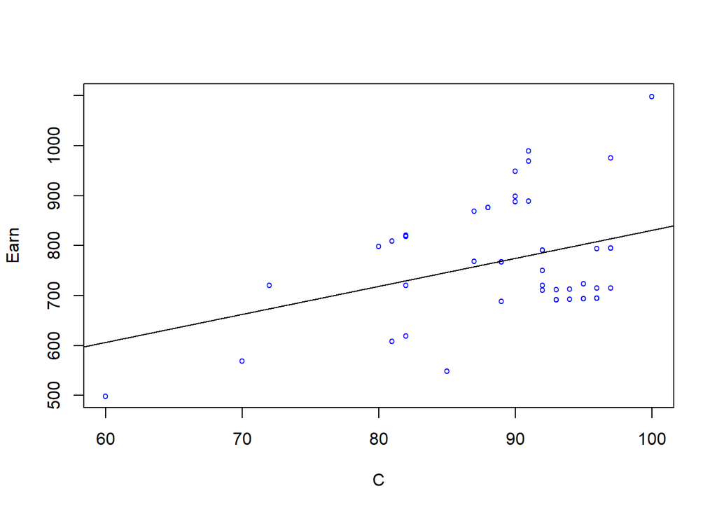

```r
> plot(df$C, df$Earn, pch = "o", col='blue', cex = 0.6, xlab = 'C', ylab = 'Earn')
> abline(lm(Earn ~ C))
```

```r
> lm(Earn ~ C)

Call:
lm(formula = Earn ~ C)

Coefficients:
(Intercept)            C
    268.885        5.622
> mymodelEarnC <- lm(Earn ~ C)
> summary(mymodelEarnC)

Call:
lm(formula = Earn ~ C)

Residuals:
    Min      1Q  Median      3Q     Max
-196.75  -97.60  -14.91   90.61  268.92

Coefficients:
            Estimate Std. Error t value Pr(>|t|)
(Intercept)  268.885    184.919   1.454  0.15272
C              5.622      2.067   2.720  0.00917 **
---
Signif. codes:  0 '***' 0.001 '**' 0.01 '*' 0.05 '.' 0.1 ' ' 1

Residual standard error: 110.5 on 46 degrees of freedom
Multiple R-squared:  0.1386,    Adjusted R-squared:  0.1199
F-statistic: 7.401 on 1 and 46 DF,  p-value: 0.009172
```

The model is
$$Earn = 268.885 + 5.622C + \varepsilon.$$
The `summary` function returns:

- the method
- the five-number summary of the residuals
- the coefficients - estimates, standard error, t-value and p-value ($H_0: \beta_i = 0$, $H_A: \beta_i \neq 0$), small p-value is flagged with `***` and means that the coefficients are statistically significant.

Other test of hypotheses are easily done knowing estimates, standard error and standard error for the residuals.

$R^2$ is interpreted as the **fraction of the variance explained by the model**.

Finally the F-statistic is given. The p-value for this is from the hypotheses test that $H_0: \beta_1 = \beta_2 = \ldots = \beta_r = 0$. Meaning that the regression is not appropriate. The theory for this comes from that of the **analysis of variance (ANOVA)** that we will speak about in the next topic.

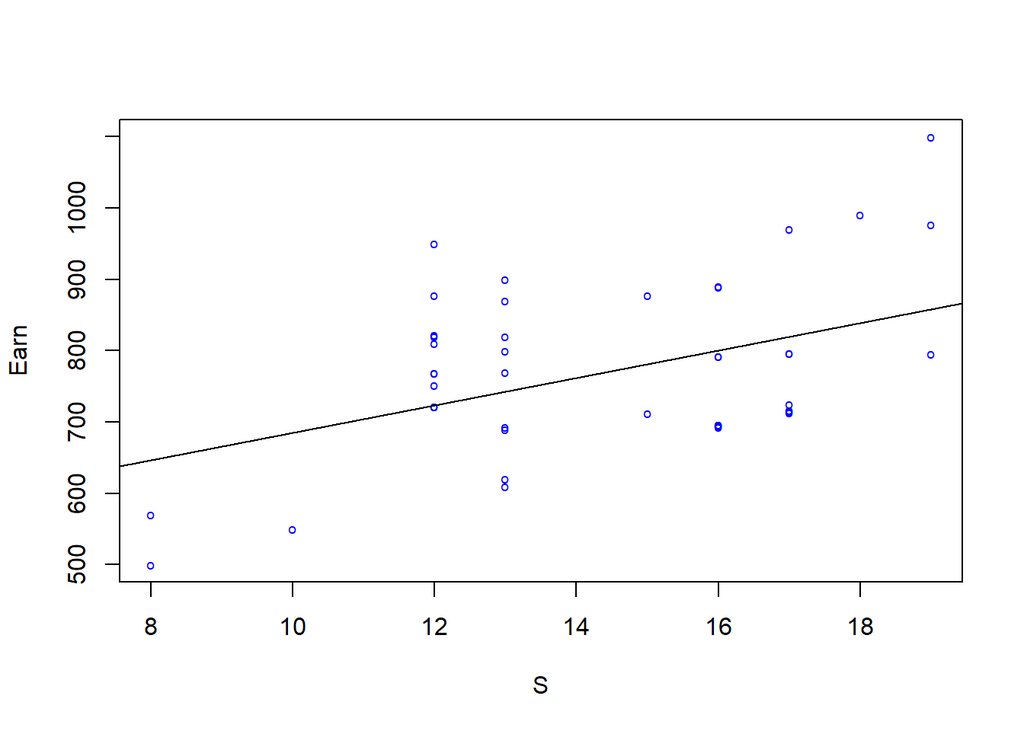

```r
> plot(S, Earn, pch = "o", col='blue', cex = 0.6, xlab = 'S', ylab = 'Earn')
> abline(lm(Earn ~ S))
```

```r
> lm(Earn ~ S)

Call:
lm(formula = Earn ~ S)

Coefficients:
(Intercept)            S
     493.15        19.21
> mymodelEarnS <- lm(Earn ~ S)
> summary(mymodelEarnS)

Call:
lm(formula = Earn ~ S)

Residuals:
     Min       1Q   Median       3Q      Max
-146.811 -104.475   -8.475   89.775  241.901

Coefficients:
            Estimate Std. Error t value Pr(>|t|)
(Intercept)  493.146     84.799   5.815 5.47e-07 ***
S             19.208      5.784   3.321  0.00176 **
---
Signif. codes:  0 '***' 0.001 '**' 0.01 '*' 0.05 '.' 0.1 ' ' 1

Residual standard error: 106.9 on 46 degrees of freedom
Multiple R-squared:  0.1934,    Adjusted R-squared:  0.1759
F-statistic: 11.03 on 1 and 46 DF,  p-value: 0.001763
```

The model is
$$Earn = 493.146 + 19.208S + \varepsilon.$$
The `summary` function returns:

- the method
- the five-number summary of the residuals
- the coefficients - estimates, standard error, $t-value = t_{emp}$ and p-value for testing $H_0: \beta_i = 0$, against $H_A: \beta_i \neq 0$. Small p-value is flagged with `***` and means that the coefficients are statistically significant.

Other test of hypotheses are easily done after knowing these estimates, their standard errors and the standard error for the residuals.

$R^2$ is the coefficient of determination and is interpreted as the **fraction of the variance explained by the model**.

Finally the F-statistic is given. It will be explained later on. Its p-value is for testing hypotheses $H_0: \beta_1 = \beta_2 = \ldots = \beta_r = 0$. Meaning that the regression is not appropriate. The model is NOT adequate. The independent variables dos not determine $Y$ at all. The theory for this comes from that of the **analysis of variance (ANOVA)** that we will speak about in the next topic.

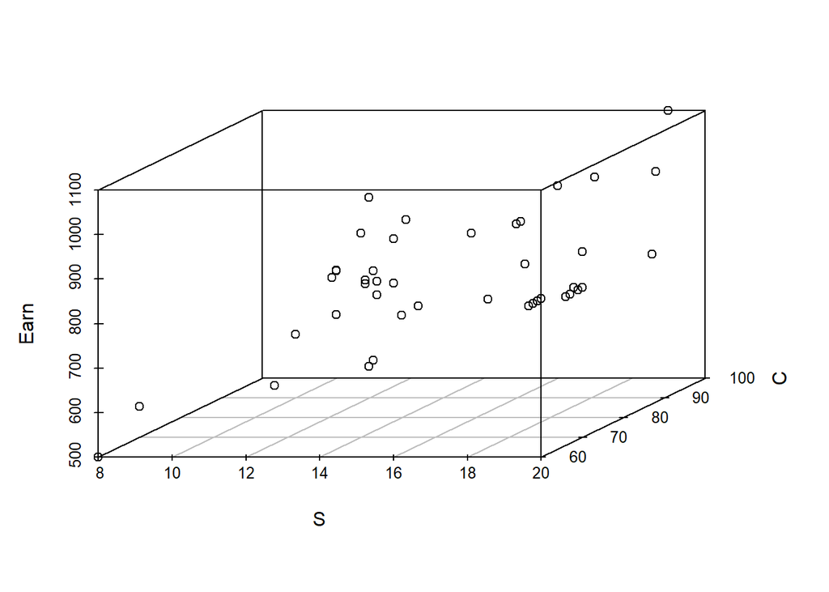

```r
> library(scatterplot3d)
Warning: package 'scatterplot3d' was built under R version 4.0.3
> scatterplot3d(S, C, Earn)
```

```r
> library(rgl)
> open3d()
wgl
  1
> plot3d(S, C, Earn, col = "red", size = 3)
```

In order to estimate the coefficients in the model
$$Earn = \beta_0 + \beta_1S + \beta_2C + \varepsilon.$$
we use again the function `lm`.

```r
> mymodel <- lm(Earn ~ S + C, data = df)
> summary(mymodel)

Call:
lm(formula = Earn ~ S + C, data = df)

Residuals:
     Min       1Q   Median       3Q      Max
-139.897 -104.855   -7.961   91.739  241.778

Coefficients:
            Estimate Std. Error t value Pr(>|t|)
(Intercept) 451.0495   208.2405   2.166   0.0356 *
S            17.4389     9.8882   1.764   0.0846 .
C             0.7583     3.4189   0.222   0.8255
---
Signif. codes:  0 '***' 0.001 '**' 0.01 '*' 0.05 '.' 0.1 ' ' 1

Residual standard error: 108 on 45 degrees of freedom
Multiple R-squared:  0.1943,    Adjusted R-squared:  0.1585
F-statistic: 5.425 on 2 and 45 DF,  p-value: 0.007748
```

The plane we are looking for is
$$Earn = 451.0495 + 17.4389 S + 0.7583 C.$$

If $C$ and $S$ were independent we would have one and the same coefficients in front of the same independents variables in the simple regression models considered in a) and b). The last means that **we observe multicollinearity**.

We can see the components of `mymodel` by

```r
> ls(mymodel)
 [1] "assign"        "call"          "coefficients"  "df.residual"
 [5] "effects"       "fitted.values" "model"         "qr"
 [9] "rank"          "residuals"     "terms"         "xlevels"
```

4. By using this equation we obtain that

```r
> Earn_16_89 <- mymodel$coefficients[1] + mymodel$coefficients[2] * 16 +  mymodel$coefficients[3] * 89; Earn_16_89
(Intercept)
   797.5635
```

We can see the coefficients via the function `summary`

```r
> summary(mymodel)

Call:
lm(formula = Earn ~ S + C, data = df)

Residuals:
     Min       1Q   Median       3Q      Max
-139.897 -104.855   -7.961   91.739  241.778

Coefficients:
            Estimate Std. Error t value Pr(>|t|)
(Intercept) 451.0495   208.2405   2.166   0.0356 *
S            17.4389     9.8882   1.764   0.0846 .
C             0.7583     3.4189   0.222   0.8255
---
Signif. codes:  0 '***' 0.001 '**' 0.01 '*' 0.05 '.' 0.1 ' ' 1

Residual standard error: 108 on 45 degrees of freedom
Multiple R-squared:  0.1943,    Adjusted R-squared:  0.1585
F-statistic: 5.425 on 2 and 45 DF,  p-value: 0.007748
```

```r
> yhat <- mymodel$fitted.values; yhat
       1        2        3        4        5        6        7        8
636.0606 643.6439 689.8967 743.7301 745.2468 746.0051 739.9385 739.1801
       9       10       11       12       13       14       15       16
738.4218 743.7301 739.9385 721.7412 722.4995 722.4995 714.9163 722.4995
      17       18       19       20       21       22       23       24
730.0828 728.5662 730.0828 727.8078 727.8078 727.0495 779.3663 816.5191
      25       26       27       28       29       30       31       32
833.9580 855.9469 858.2219 855.1886 782.3996 818.0358 818.7941 819.5524
      33       34       35       36       37       38       39       40
820.3108 821.0691 821.0691 821.0691 802.8718 802.8718 802.1135 800.5969
      41       42       43       44       45       46       47       48
802.8718 801.3552 802.1135 799.8385 799.0802 798.3219 799.8385 748.2801
```

or

```r
> yhat <- mymodel$coefficients[1] + mymodel$coefficients[2] * S +  mymodel$coefficients[3] * C; yhat
 [1] 636.0606 643.6439 689.8967 743.7301 745.2468 746.0051 739.9385 739.1801
 [9] 738.4218 743.7301 739.9385 721.7412 722.4995 722.4995 714.9163 722.4995
[17] 730.0828 728.5662 730.0828 727.8078 727.8078 727.0495 779.3663 816.5191
[25] 833.9580 855.9469 858.2219 855.1886 782.3996 818.0358 818.7941 819.5524
[33] 820.3108 821.0691 821.0691 821.0691 802.8718 802.8718 802.1135 800.5969
[41] 802.8718 801.3552 802.1135 799.8385 799.0802 798.3219 799.8385 748.2801
```

```r
> e <- resid(mymodel); e
           1            2            3            4            5            6
-136.0606242  -73.6439079 -139.8966818   26.2698889  -55.2467679  153.9949038
           7            8            9           10           11           12
-119.9384693 -129.1801409   61.5781875  126.2698889   80.0615307   88.2587833
          13           14           15           16           17           18
  97.5004549   -0.4995451    7.0837386   99.5004549   -8.0828288  221.4338279
          19           20           21           22           23           24
  21.9171712   41.1921563   41.1921563  150.9504847   98.6337122  154.4808787
          25           26           27           28           29           30
 157.0419545  121.0530601  241.7780750  -59.1886115  -70.3996013 -105.0357781
          31           32           33           34           35           36
-104.7941064  -94.5524348 -104.3107632 -104.0690915  -24.0690915  -24.0690915
          37           38           39           40           41           42
-106.8718390 -106.8718390 -107.1135106 -107.5968539 -106.8718390 -107.3551823
          43           44           45           46           47           48
-107.1135106   -7.8385255   91.9198029   91.6781312   -7.8385255  -55.2800813
```

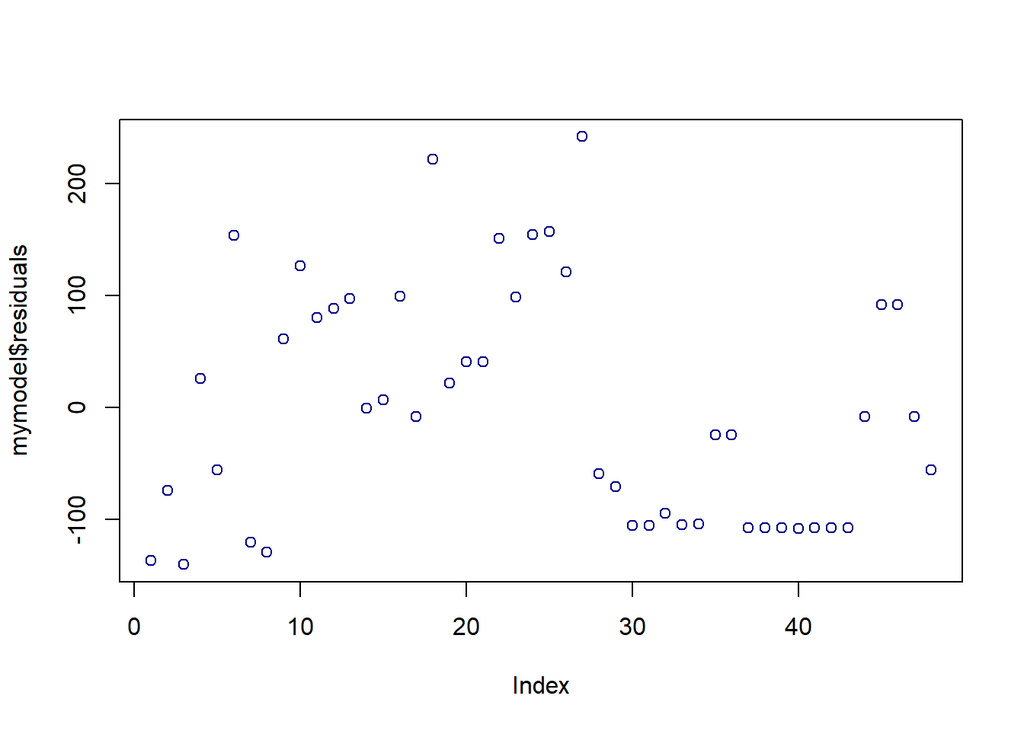

```r
> plot(mymodel$residuals, col = "darkblue")
```

or by using the formula

```r
> e <- Earn - yhat; e
 [1] -136.0606242  -73.6439079 -139.8966818   26.2698889  -55.2467679
 [6]  153.9949038 -119.9384693 -129.1801409   61.5781875  126.2698889
[11]   80.0615307   88.2587833   97.5004549   -0.4995451    7.0837386
[16]   99.5004549   -8.0828288  221.4338279   21.9171712   41.1921563
[21]   41.1921563  150.9504847   98.6337122  154.4808787  157.0419545
[26]  121.0530601  241.7780750  -59.1886115  -70.3996013 -105.0357781
[31] -104.7941064  -94.5524348 -104.3107632 -104.0690915  -24.0690915
[36]  -24.0690915 -106.8718390 -106.8718390 -107.1135106 -107.5968539
[41] -106.8718390 -107.3551823 -107.1135106   -7.8385255   91.9198029
[46]   91.6781312   -7.8385255  -55.2800813
```

g.) It is time to determine the **mean square error** of the multiple model.

$$MSE = RSE^2 = S_\varepsilon^2 = \frac{1}{n - 3}\sum_{i=1}^n{(\hat{Y_i} - Y_i)^2} = \frac{1}{n - 3}\sum_{i=1}^n{\varepsilon_i^2}$$
It is an unbiased estimator of $\sigma_\varepsilon^2$. The denominator $n - 3$ comes from the fact that there are three values estimated from the data: $\beta_0$, $\beta_1$ and $\beta_2$.

Let us remind that

```r
> SSE <- sum(e^2); SSE
[1] 525183
> MSE <- SSE / (n - 3); MSE
[1] 11670.73
```

```r
> s <- sqrt(MSE); s
[1] 108.0312
```

The **Residual Standard error** is
$$S_\varepsilon = \sqrt{MSE} = \sqrt{\frac{SSE}{n-3}} = 108.0312\ EUR$$
or we can extract it via the function `summary`

```r
> summary(mymodel)

Call:
lm(formula = Earn ~ S + C, data = df)

Residuals:
     Min       1Q   Median       3Q      Max
-139.897 -104.855   -7.961   91.739  241.778

Coefficients:
            Estimate Std. Error t value Pr(>|t|)
(Intercept) 451.0495   208.2405   2.166   0.0356 *
S            17.4389     9.8882   1.764   0.0846 .
C             0.7583     3.4189   0.222   0.8255
---
Signif. codes:  0 '***' 0.001 '**' 0.01 '*' 0.05 '.' 0.1 ' ' 1

Residual standard error: 108 on 45 degrees of freedom
Multiple R-squared:  0.1943,    Adjusted R-squared:  0.1585
F-statistic: 5.425 on 2 and 45 DF,  p-value: 0.007748
```

8. Via the function `summary` we can estimate also the **coefficient of determination**. Note that it is **Adjusted R-squared: 0.1585**
   $$cor^2(X,Y) = 1 - \frac{\mathbb{E}\varepsilon^2}{\mathbb{D}Y}, \quad R^2 = Adjusted\ R-squared = 0.1585,$$
   The coefficient is not close to $1$, therefore, we cannot say that the independent variables

$X_1 = S$ - the years spent for education in school/university, and

$X_2 = C$ - the results from a cognitive test for imagination

are important for the value of the dependent variable

$Y = Earn$ - the monthly salary in EUR for peoples in this population.

We can determine it also via the formula

```r
> Rsquare <- 1 - MSE/var(Earn); Rsquare
[1] 0.1584657
```

The other result **Multiple R-squared: 0.1942757** does not take into account that the denominators of the estimators $S_\varepsilon^2$ and $S_Y^2 = \frac{1}{n-1}\sum_{i=1}^n(Y_i - \bar{Y}_n)^2$ are different and computes
$$Multiple\ R-squared = 1 - \frac{SSE}{\sum_{i=1}^n(Y_i - \bar{Y}_n)^2} = 0.1942757$$

```r
> Rsq <- 1 - SSE/sum((Earn - mean(Earn))^2); Rsq
[1] 0.1942757
```

1. In order to check if $\mathbb{E}\varepsilon = 0$ we use `t-test`.

$H_0: \mathbb{E}\varepsilon = 0$

$H_A: \mathbb{E}\varepsilon \neq 0$

```r
> mean(e)
[1] -3.434317e-13
> n <- length(e); n
[1] 48
> rse <- sqrt(MSE); rse
[1] 108.0312
> temp <- abs(mean(e) - 0) / (rse / sqrt(n)); temp
[1] 2.20248e-14
> pvalue <- 2 * pt(temp, n - 1, lower.tail = FALSE); pvalue
[1] 1
```

The $p-value = 1 > 0.05 = \alpha$, so we have no evidence to reject $H_0$.

11. The next step is to test the assumptions of the model that the residuals are i.i.d. normally distributed $\varepsilon_i \in N(0, \sigma_\varepsilon^2)$

First we make the normal `qq-plot`

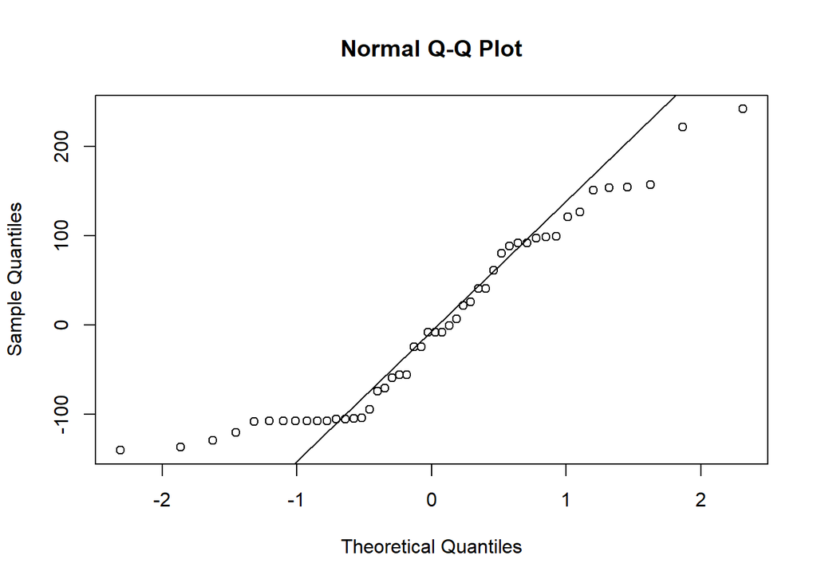

```r
> qqnorm(e)
> qqline(e)
```

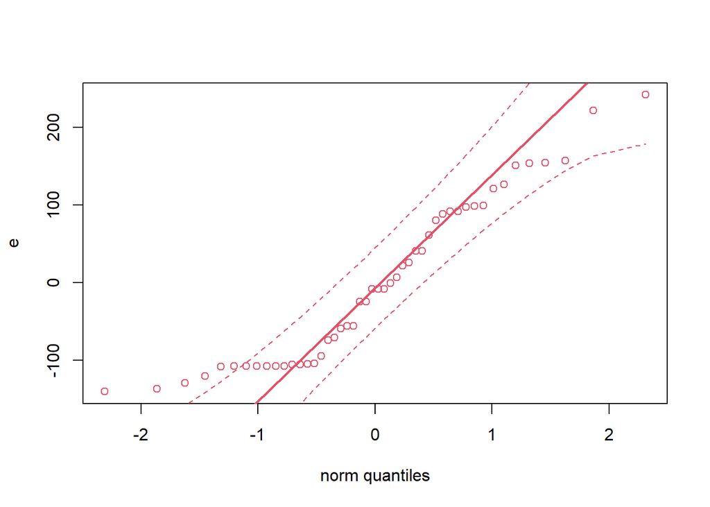

```r
> library(StatDA)
Warning: package 'StatDA' was built under R version 4.0.3
Loading required package: sgeostat
Warning: package 'sgeostat' was built under R version 4.0.3
Registered S3 method overwritten by 'geoR':
  method         from
  plot.variogram sgeostat
> qqplot.das(e)
```

We can perform also Shapiro test

$H_0: \varepsilon$ is normally distributed

$H_A: \varepsilon$ is not normally distributed

We use the function `shapiro.test` in R

```r
> shapiro.test(e)

    Shapiro-Wilk normality test

data:  e
W = 0.91997, p-value = 0.002966
```

The $p-value = 0.002966 < 0.05 = \alpha$, so we reject $H_0$. We have no reason to assume that the data come from normal distribution.

# Confidence intervals for $\hat{Y} = (Y|X)$

If the errors are normal we can estimate the accuracy of these considerations.

Let us add some normal noise $\varepsilon \in N(0, 2^2)$ with a small variance and see what will happen with the response variable $Y = Earn$

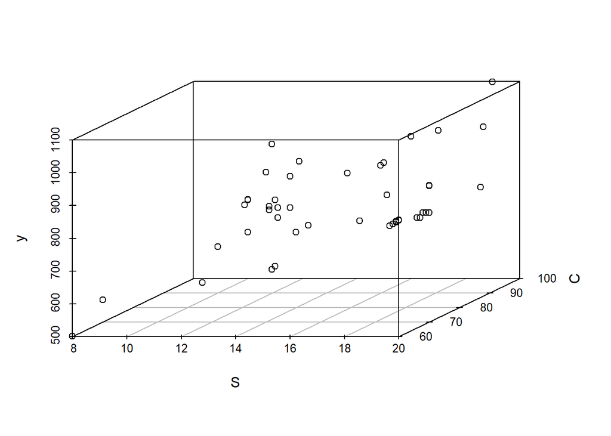

```r
> y <- Earn + rnorm(n, 0, 2)
> scatterplot3d(S, C, y)
```

```r
> mymodel <- lm(y ~ S + C, data = df)
> summary(mymodel)

Call:
lm(formula = y ~ S + C, data = df)

Residuals:
     Min       1Q   Median       3Q      Max
-136.763 -105.727   -9.923   91.378  242.017

Coefficients:
            Estimate Std. Error t value Pr(>|t|)
(Intercept) 449.3321   208.2493   2.158   0.0363 *
S            17.2420     9.8886   1.744   0.0881 .
C             0.8045     3.4191   0.235   0.8151
---
Signif. codes:  0 '***' 0.001 '**' 0.01 '*' 0.05 '.' 0.1 ' ' 1

Residual standard error: 108 on 45 degrees of freedom
Multiple R-squared:  0.1929,    Adjusted R-squared:  0.157
F-statistic: 5.378 on 2 and 45 DF,  p-value: 0.008051
```

We observe that the small variance almost does not change the model.

And what will happen if we add normal noise $\varepsilon \in N(0, 100^2)$ with a higher variance

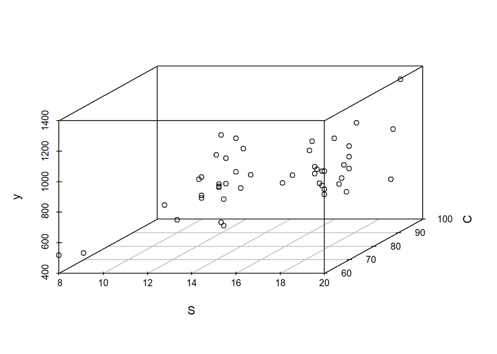

```r
> y <- Earn + rnorm(n, 0, 100)
> scatterplot3d(S, C, y)
```

```r
> mymodel <- lm(y ~ S + C, data = df)
> summary(mymodel)

Call:
lm(formula = y ~ S + C, data = df)

Residuals:
    Min      1Q  Median      3Q     Max
-239.25  -90.99  -30.88  110.70  415.91

Coefficients:
            Estimate Std. Error t value Pr(>|t|)
(Intercept)  121.329    295.688   0.410    0.684
S             13.538     14.041   0.964    0.340
C              5.196      4.855   1.070    0.290

Residual standard error: 153.4 on 45 degrees of freedom
Multiple R-squared:  0.1922,    Adjusted R-squared:  0.1563
F-statistic: 5.353 on 2 and 45 DF,  p-value: 0.008214
```

We observe that when we add more noise the guesses of $Y = Earn$ got worse and worse. The more noise the worse the confidence. Later on we will see that the more data the better the confidence.

For the confidence intervals we will need the estimator of
$$cov(\hat{\vec{\beta}}) = cov((\mathbb{X}^{T}\mathbb{X})^{-1}\mathbb{X}^{T}\vec{Y}) = cov((\mathbb{X}^{T}\mathbb{X})^{-1}\mathbb{X}^{T}(\mathbb{X}\vec{\beta} + \vec{\varepsilon})) = cov(\vec{\beta} + (\mathbb{X}^{T}\mathbb{X})^{-1}\mathbb{X}^{T}\vec{\varepsilon})$$
$$= cov((\mathbb{X}^{T}\mathbb{X})^{-1}\mathbb{X}^{T}\vec{\varepsilon}) = (\mathbb{X}^{T}\mathbb{X})^{-1}\mathbb{X}^{T}cov(\vec{\varepsilon})((\mathbb{X}^{T}\mathbb{X})^{-1}\mathbb{X}^{T})^T =(\mathbb{X}^{T}\mathbb{X})^{-1}\mathbb{X}^{T}\sigma_\varepsilon^2\mathbb{I}((\mathbb{X}^{T}\mathbb{X})^{-1}\mathbb{X}^{T})^T$$
$$= \sigma_\varepsilon^2(\mathbb{X}^{T}\mathbb{X})^{-1}\mathbb{X}^{T}((\mathbb{X}^{T}\mathbb{X})^{-1}\mathbb{X}^{T})^T= \sigma_\varepsilon^2(\mathbb{X}^{T}\mathbb{X})^{-1}\mathbb{X}^{T}\mathbb{X}((\mathbb{X}^{T}\mathbb{X})^{-1})^T = \sigma_\varepsilon^2((\mathbb{X}^{T}\mathbb{X})^{-1})^T = \sigma_\varepsilon^2(\mathbb{X}^{T}\mathbb{X})^{-1}$$
Therefore,
$$\hat{\vec{\beta}} \in N(\vec{\beta};\sigma_\varepsilon^2(\mathbb{X}^{T}\mathbb{X})^{-1}).$$
and the unbiased estimator of $\mathbb{D}\hat{\beta_i}$ is
$$S_{\beta_i}^2 := S_\varepsilon^2 ((\mathbb{X}^{T}\mathbb{X})^{-1})_{ii}, \quad SE(\beta_i) = S_{\beta_i}, \quad i = 1, 2, ..., r.$$
Correspondingly
$$\frac{\hat{\beta_i} - \beta_i}{S_{\beta_i}} \in t(n-r-1), \quad i = 1, 2, ..., r.$$
And the $(1-\alpha)100\%$ confidence interval for $\beta_i$ is
$$[\hat{\beta_i} - t_{1-\frac{\alpha}{2}; t(n-r-1)}S_{\beta_i};\hat{\beta_i} + t_{1-\frac{\alpha}{2}; t(n-r-1)}S_{\beta_i}], \quad i = 1, 2, ..., r$$
The `summary` function returns the estimators $\hat{\beta}_i$ of the coefficients $\beta_i$, $i = 1, 2, ..., r$, their standard errors $SE(\beta_i) = S_{\beta_i}$, the corresponding $t-values = t_{emp} = \frac{\hat{\beta_i} - 0}{S_{\beta_i}}$ and the corresponding $p-values = \mathbb{P}(|\eta| > t_{emp})$, where $\eta \in t(n-r-1)$ They can be used for testing

$H_0: \beta_i = 0$,

$H_A: \beta_i \neq 0$

The small p-value is flagged with `***` and means that the coefficients are statistically significant.

Other test of hypotheses are easily done knowing estimates, standard error and standard error for the residuals.

When predict $Y$ given $\vec{X}$ we will need
$$\mathbb{D}(\hat{Y}) = \mathbb{D}(Y|\vec{X}) = \mathbb{D}(\hat{\vec{\beta}}^T\vec{X}) = cov(\hat{\vec{\beta}}^T\vec{X},\hat{\vec{\beta}}^T\vec{X}) = \vec{X}cov(\hat{\vec{\beta}})\vec{X}^T = \vec{X}\sigma_\varepsilon^2(\mathbb{X}^{T}\mathbb{X})^{-1}\vec{X}^T = \sigma_\varepsilon^2\vec{X}(\mathbb{X}^{T}\mathbb{X})^{-1}\vec{X}^T$$
and therefore, we estimate it via
$$S_{\hat{Y}}^2 = S_{\varepsilon}^2\vec{X}(\mathbb{X}^{T}\mathbb{X})^{-1}\vec{X}^T$$
We also obtained that
$$\hat{Y} = (Y|\vec{X}) \in N(\vec{\beta}^T\vec{X}; \sigma_\varepsilon^2\vec{X}(\mathbb{X}^{T}\mathbb{X})^{-1}\vec{X}^T)$$
therefore, the $(1-\alpha)100$% confidence interval for $\hat{Y}$ is
$$[\hat{\vec{\beta}}^T\vec{X} - t_{1-\frac{\alpha}{2}; t(n-r-1)}S_{\hat{Y}};\hat{\vec{\beta}}^T\vec{X} + t_{1-\frac{\alpha}{2}; t(n-r-1)}S_{\hat{Y}}].$$